# Introdução a Lógica de Programação

## Programas Compilados

Em uma linguagem compilada, existe um passo prévio chamado **compilação**. Um programa especial (o compilador) lê todo o código-fonte de uma vez, verifica erros e o traduz integralmente em um arquivo binário executável (como um `.exe` no Windows).

### Linguagem C/C++

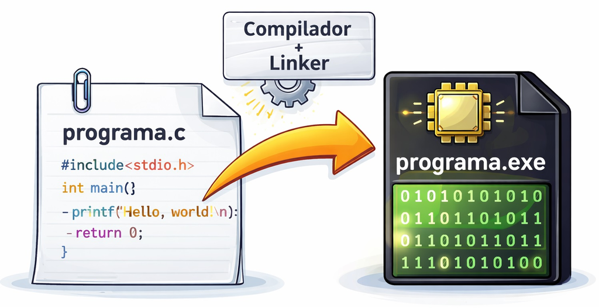

### Linguagem JAVA

[figure not shown]

## Programas Interpretados

Em uma linguagem interpretada, o código não é transformado em um arquivo binário antes da execução. Em vez disso, um programa chamado **interpretador** lê o código-fonte e o executa linha por linha, em tempo real.

### Linguagem PYTHON

[figure not shown]

### Linguagem JAVASCRIPT

[figure not shown]

Resumo das vantagens e desvantagens dos 2 paradigmas:

| **Característica** | **Programas Compilados** | **Programas Interpretados** |
| --- | --- | --- |
| **Desempenho** | **Vantagem:** Muito rápidos, pois o código já está em linguagem de máquina otimizado. | **Desvantagem:** Mais lentos, devido ao “overhead” de traduzir o código enquanto ele executa. |
| **Portabilidade** | **Desvantagem:** O binário é gerado para um sistema específico (ex: um app de Windows não roda no Linux). | **Vantagem:** O código roda em qualquer sistema que tenha o interpretador instalado. |
| **Desenvolvimento** | **Desvantagem:** O ciclo é mais lento, pois toda mudança exige uma nova compilação total. | **Vantagem:** Testes rápidos. Você altera uma linha e roda o programa instantaneamente. |
| **Privacidade** | **Vantagem:** O código-fonte original fica protegido, pois você distribui apenas o binário. | **Desvantagem:** Geralmente o código-fonte precisa ser distribuído ou é facilmente legível. |
| **Depuração (Debug)** | **Complexo:** Erros podem ser difíceis de rastrear após a compilação. | **Simples:** O interpretador aponta exatamente a linha que falhou durante a execução. |
| **Uso de Memória** | **Vantagem:** Consomem menos memória, pois não precisam de um tradutor rodando junto. | **Desvantagem:** Consomem mais recursos por manterem o interpretador ativo na memória. |

## Início de Desenvolvimento: Operações básicas de linguagens de alto-nível

| Operação | Analogia Humana | Função Principal |
| --- | --- | --- |
| Escrever | Falar / Mostrar | Exibir informações para o usuário. |
| Ler | Ouvir / Observar | Obter dados externos para o sistema. |
| Decidir | Escolher um caminho | Criar bifurcações lógicas no fluxo. |
| Repetir | Rotina de exercícios | Automatizar tarefas cíclicas e exaustivas. |
| Funções | Receita de bolo | Agrupar comandos para reutilização. |

### Escrever na tela (Saída de Dados)

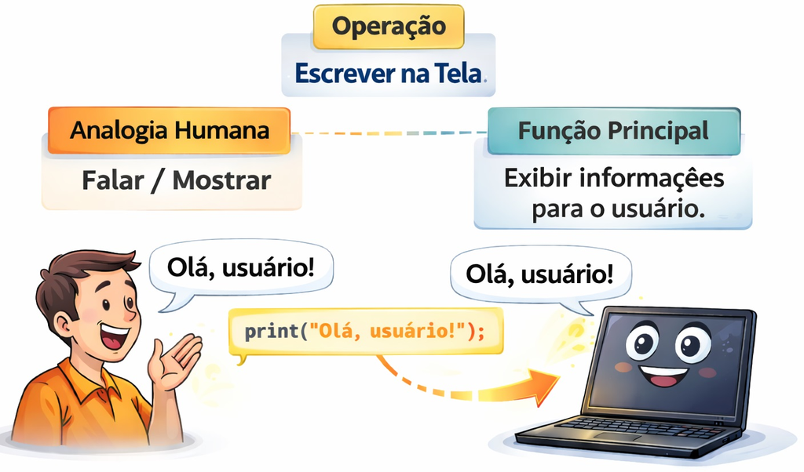

É a forma como o programa se comunica com o usuário. Ele “cospe” informações processadas ou mensagens de instrução para que possamos ver o que está acontecendo.

- **Comando comum:** `print()`, `console.log()` ou `escreva()`.
- **Exemplo:** Exibir o resultado de uma soma ou um simples “Olá, Mundo!”.

### Ler do Teclado (Entrada de Dados)

[figure not shown]

É o oposto da escrita. Aqui, o programa “ouve” o usuário. Ele interrompe a execução e espera que você digite algo para salvar essa informação em uma **variável**.

- **Comando comum:** `input()`, `scanf()` ou `leia()`.

### Repetir Operações (Laços de Repetição)

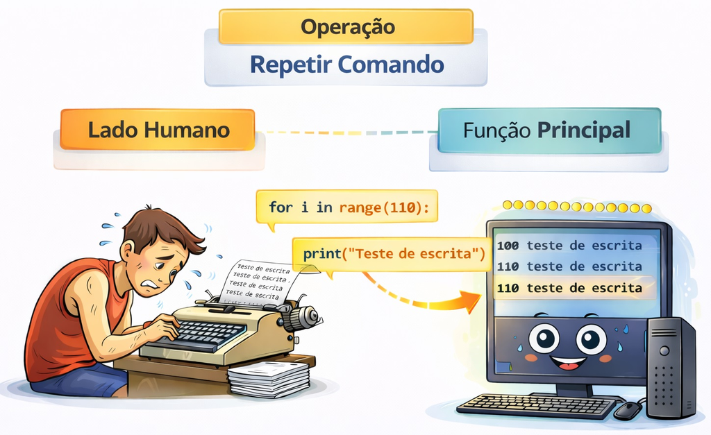

Computadores são ótimos em fazer tarefas repetitivas sem reclamar. Em vez de escrever o mesmo código dez vezes, usamos um laço (loop) que executa o bloco de comandos enquanto uma condição for mantida.

- **Tipos comuns:** `while` (enquanto) e `for` (para).
- **Exemplo:** Listar todos os nomes de uma lista de contatos ou repetir um alerta até que o usuário clique em “OK”.

### Decidir (Estruturas Condicionais )

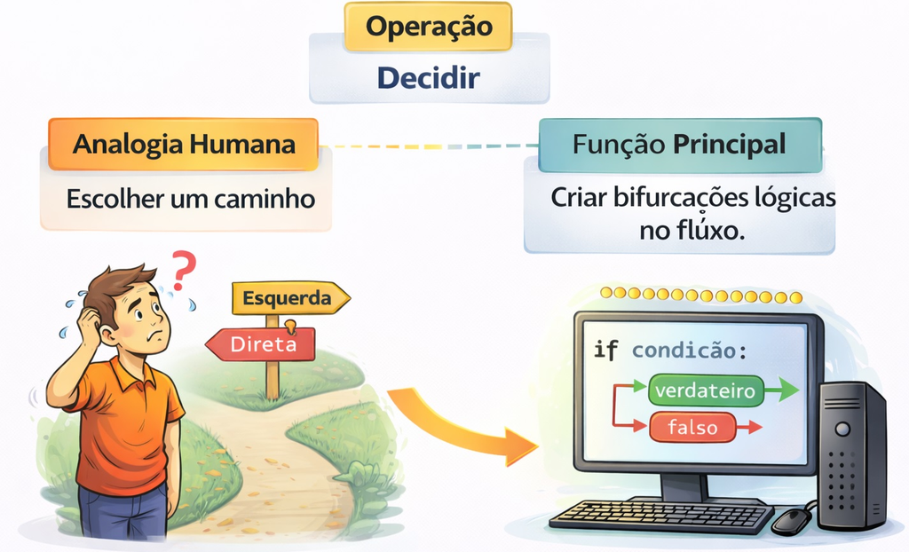

A inteligência de um código nasce aqui. Essa operação permite que o programa tome caminhos diferentes baseando-se em uma condição lógica (verdadeira ou falsa).

- **Lógica:** **SE** (condição) então faça A; **SENÃO**, faça B.
- **Exemplo:** Se a nota for maior que 7, o aluno está “Aprovado”; caso contrário, “Reprovado”.

### Procedimentos e Funções (Modularização)

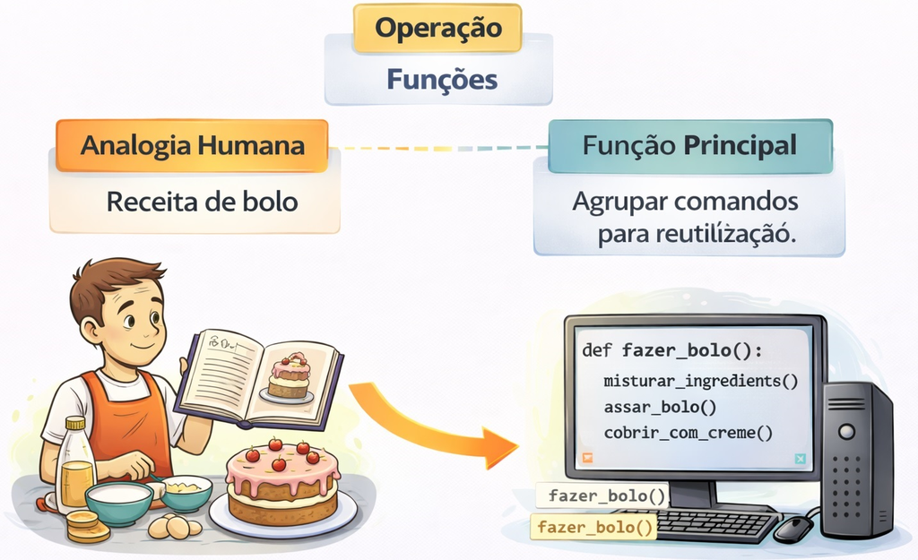

Imagine que você precisa calcular o imposto de renda em vários lugares do seu código. Em vez de repetir a fórmula toda vez, você cria uma “caixinha” com esse cálculo.

- **Procedimento:** Executa uma tarefa, mas não devolve um valor (ex: limpar a tela).
- **Função:** Executa um cálculo e **retorna** um resultado para quem a chamou.
- **Vantagem:** Deixa o código organizado, fácil de ler e evita a repetição desnecessária (princípio DRY - *Don’t Repeat Yourself*).

## O que são Algoritmos ?

Algoritmos são uma **quantidade finita de passos** para a resolução de um problema.

| Propriedades: | Descrição: |
| --- | --- |
| 1) Algoritmos possuem uma entrada bem definida; | O ponto de partida do processo. |
| 2) Saída bem definida; | Geram um resultado esperado. |
| 3) Todas entradas de um conjunto de dados leva necessáriamente a um conjunto correspondente; | São determinísticos. |

### Exemplo-01:

Vamos fazer um algoritmo para *escrever na tela* a mensagem “meu primeiro programa” .

Use pesudo-código:

```
INÍCIO

    ESCREVER "meu primeiro programa !"

FIM
```

### Exemplo-02:

Vamos fazer um algoritmo para *ler do teclado* duas parcelas (dois números), soma-los e *escrever na tela* o resultado.

Use pseudo-código

```
Início

    Escreva "Digite a primeira parcela: "

    Leia parcela1

    Escreva "Digite a segunda parcela: "

    Leia parcela2

    soma ← parcela1 + parcela2

    Escreva "O resultado da soma é: ", soma

Fim
```

### Exemplo-03:

Vamos fazer um algoritmo para *ler do teclado* um número, e *escrever na tela* este numero.

```
Início

    Escreva "Digite um número: "

    Leia variavel_numero

    variavel_contador ← 1

    Enquanto ( variavel_contador <= 5 ) faça

        Escreva variavel_numero

        variavel_contador ← ( variavel_contador + 1 )

    FimEnquanto

Fim
```

### Exemplo-04:

Escreva um pseudo-código para ler dois números do teclado. Decida qual dos dois números é maios e escreva na tela qual dos números é maior.

```
Início
    Escreva "Digite o primeiro número: "
    Leia numero1

    Escreva "Digite o segundo número: "
    Leia numero2

    Se numero1 > numero2 então
        Escreva "O maior número é: ", numero1
    Senão
        Se numero2 > numero1 então
            Escreva "O maior número é: ", numero2
        Senão
            Escreva "Os dois números são iguais."
        FimSe
    FimSe
Fim
```

### Exemplo-05:

Escreva um pseudo-código para desenhar na tela uma moldura envolvendo outro comando de escrever na tela “meu quinto programa”. Transforme essa moldura em uma função (ou procedimento).

```
Início

Procedimento MostrarMoldura()
    Escreva "****************************"
    Escreva "*   meu quinto programa    *"
    Escreva "****************************"
FimProcedimento

    MostrarMoldura()

Fim
```

## Executando os Algoritmos Através de uma Linguagem: PYTHON

### Exemplo-06:

Vamos fazer um algoritmo para *escrever na tela* a mensagem “meu primeiro programa” .

Use a **linguagem PYTHON**:

```python
print("meu primeiro programa !")
```

```
## meu primeiro programa !
```

### Exemplo-07:

Vamos fazer um algoritmo para *ler do teclado* duas parcelas (dois números), soma-los e *escrever na tela* o resultado.

Use a **linguagem PYTHON**:

```python
parcela1 = input("Digite a primeira parcela: ")
parcela2 = input("Digite a segunda  parcela: ")

soma = parcela1 + parcela2

print("O resultado da soma é:", soma)
```

Veja o código a seguir, quase igual ao anterior

```python
parcela1 = float(input("Digite a primeira parcela: "))
parcela2 = float(input("Digite a segunda  parcela: "))

soma = parcela1 + parcela2

print("O resultado da soma é:", soma)
```

### Exemplo-08:

Vamos fazer um algoritmo para *ler do teclado* um número, e *escrever na tela* este numero.

Use a **linguagem PYTHON**:

```python
variavel_numero = input("Digite um número: ")

variavel_contador = 1

while variavel_contador <= 5:
    print(variavel_numero)
    variavel_contador = variavel_contador + 1
```

### Exemplo-09:

Escreva um pseudo-código para ler dois números do teclado. Decida qual dos dois números é maios e escreva na tela qual dos números é maior.

Use a **linguagem PYTHON**:

```python
print("Digite o primeiro número:")
numero1 = float(input())

print("Digite o segundo número:")
numero2 = float(input())

if numero1 > numero2:
    print("O maior número é:", numero1)
else:
    if numero2 > numero1:
        print("O maior número é:", numero2)
    else:
        print("Os dois números são iguais.")
```

## Executando os Algoritmos Através de uma Linguagem: C

### Exemplo-10:

Vamos fazer um algoritmo para *escrever na tela* a mensagem “meu primeiro programa” .

Use a **linguagem C**:

```c
#include <stdio.h>

int main()
{
    printf("meu primeiro programa !\n");
    return 0;
}
```

### Exemplo-11:

Vamos fazer um algoritmo para *ler do teclado* duas parcelas (dois números), soma-los e *escrever na tela* o resultado.

Use a **linguagem C**:

```c
#include <stdio.h>

int main()
{
    // 1. Declaração das variáveis (precisamos definir o tipo antes)
    float parcela1, parcela2, soma;

    // 2. Leitura da primeira parcela
    printf("Digite a primeira parcela: ");
    scanf("%f", &parcela1);

    // 3. Leitura da segunda parcela
    printf("Digite a segunda parcela: ");
    scanf("%f", &parcela2);

    // 4. Processamento (Cálculo matemático real)
    soma = parcela1 + parcela2;

    // 5. Saída formatada (%.2f limita a duas casas decimais)
    printf("O resultado da soma é: %.2f\n", soma);

    return 0;
}
```

Veja o código a seguir, quase igual ao anterior

```c
#include <stdio.h>

int main()
{
    // Definindo as "caixas" na memória para números reais
    float parcela1, parcela2, soma;

    // Entrada da primeira parcela
    printf("Digite a primeira parcela: ");
    scanf("%f", &parcela1);

    // Entrada da segunda parcela
    printf("Digite a segunda parcela: ");
    scanf("%f", &parcela2);

    // Processamento
    soma = parcela1 + parcela2;

    // Saída dos dados
    // O %.2f limita o resultado a 2 casas após a vírgula
    printf("O resultado da soma é: %.2f\n", soma);

    return 0;
}
```

### Exemplo-12:

Vamos fazer um algoritmo para *ler do teclado* um número, e *escrever na tela* este numero.

Use a **linguagem C**:

```c
#include <stdio.h>

int main()
{
  // 1. Declaração das variáveis
  int variavel_numero;
  int variavel_contador = 1;

    // 2. Entrada de dados
  printf("Digite um numero: ");
  scanf("%d", &variavel_numero);

  // 3. Estrutura de repetição (While)
  // No C, a condição DEVE estar entre parênteses ()
  while (variavel_contador <= 5)
  {
        // O que estiver dentro das chaves {} será repetido
        printf("%d\n", variavel_numero);

        // Incremento do contador
        variavel_contador = variavel_contador + 1;
  }

  return 0;
}
```

### Exemplo-13:

Escreva um pseudo-código para ler dois números do teclado. Decida qual dos dois números é maios e escreva na tela qual dos números é maior.

Use a **linguagem C**:

```python
#include <stdio.h>

int main()
{
    float numero1, numero2;

    // Entrada do primeiro número
    printf("Digite o primeiro numero:\n");
    scanf("%f", &numero1);

    // Entrada do segundo número
    printf("Digite o segundo numero:\n");
    scanf("%f", &numero2);

    // Estrutura de Decisão
    if (numero1 > numero2)
    {
        printf("O maior numero e: %.2f\n", numero1);
    }
    else
    if (numero2 > numero1)
    {
        printf("O maior numero e: %.2f\n", numero2);
    }
    else
    {
        printf("Os dois numeros sao iguais.\n");
    }

    return 0;
}
```

## Executando os Algoritmos Através de uma Linguagem: JAVA

### Exemplo-14:

Vamos fazer um algoritmo para *escrever na tela* a mensagem “meu primeiro programa” .

Use a **linguagem JAVA**:

```c
public class PrimeiroPrograma
{
    public static void main(String[] args)
    {
      // No Java, usamos System.out.println para imprimir e pular linha
      System.out.println("meu primeiro programa !");
    }
}
```

### Exemplo-15:

Vamos fazer um algoritmo para *ler do teclado* duas parcelas (dois números), soma-los e *escrever na tela* o resultado.

Use a **linguagem JAVA**:

```c
import java.util.Scanner; // Importa a ferramenta de leitura

public class ConcatenarParcelas
{
    public static void main(String[] args)
    {
        Scanner leitor = new Scanner(System.in);

        // No Java, precisamos declarar que as variáveis são do tipo String
        System.out.print("Digite a primeira parcela: ");
        String parcela1 = leitor.nextLine();

        System.out.print("Digite a segunda parcela: ");
        String parcela2 = leitor.nextLine();

        // O sinal de + entre Strings junta os textos (concatenação)
        String soma = parcela1 + parcela2;

        System.out.println("O resultado da soma é: " + soma);

        leitor.close();
    }
}
```

Veja o código a seguir, quase igual ao anterior

```c
import java.util.Scanner; // Importa a biblioteca para leitura de dados

public class SomaReais
{
    public static void main(String[] args)
    {
        // Criamos um objeto Scanner para ler a entrada do teclado
        Scanner leitor = new Scanner(System.in);

        // Definindo as variáveis para números reais
        float parcela1, parcela2, soma;

        // Entrada da primeira parcela
        System.out.print("Digite a primeira parcela: ");
        parcela1 = leitor.nextFloat();

        // Entrada da segunda parcela
        System.out.print("Digite a segunda parcela: ");
        parcela2 = leitor.nextFloat();

        // Processamento
        soma = parcela1 + parcela2;

        // Saída dos dados
        // O Java também aceita o printf igualzinho ao C!
        System.out.printf("O resultado da soma é: %.2f\n", soma);

        // Fechamos o leitor por boa prática
        leitor.close();
    }
}
```

### Exemplo-16:

Vamos fazer um algoritmo para *ler do teclado* um número, e *escrever na tela* este numero.

Use a **linguagem JAVA**:

```c
import java.util.Scanner; // Importa a classe Scanner para leitura de dados

public class RepeticaoWhile
{
    public static void main(String[] args)
    {
        // Criamos o objeto leitor para o teclado
        Scanner leitor = new Scanner(System.in);

        // 1. Declaração das variáveis
        int variavelNumero;
        int variavelContador = 1;

        // 2. Entrada de dados
        System.out.print("Digite um numero: ");
        variavelNumero = leitor.nextInt(); // Lê um número inteiro

        // 3. Estrutura de repetição (While)
        // Assim como no C, a condição fica entre parênteses ()
        while (variavelContador <= 5)
        {
            // No Java, o println já pula linha automaticamente
            System.out.println(variavelNumero);

            // Incremento do contador
            variavelContador = variavelContador + 1;
        }

        // Fechar o leitor por boa prática
        leitor.close();
    }
}
```

### Exemplo-17:

Escreva um pseudo-código para ler dois números do teclado. Decida qual dos dois números é maios e escreva na tela qual dos números é maior.

Use a **linguagem JAVA**:

```python
import java.util.Scanner;

public class CompararNumeros
{
    public static void main(String[] args)
    {
        Scanner leitor = new Scanner(System.in);
        float numero1, numero2;

        // Entrada do primeiro número
        System.out.println("Digite o primeiro numero:");
        numero1 = leitor.nextFloat();

        // Entrada do segundo número
        System.out.println("Digite o segundo numero:");
        numero2 = leitor.nextFloat();

        // Estrutura de Decisão
        if (numero1 > numero2)
        {
            System.out.printf("O maior numero e: %.2f\n", numero1);
        }
        else if (numero2 > numero1) {
            System.out.printf("O maior numero e: %.2f\n", numero2);
        }
        else
        {
            System.out.println("Os dois numeros sao iguais.");
        }

        leitor.close();
    }
}
```

### Ferramentas:

#### Instalar o Microsoft Build Tools VS2022

```
winget install --id=Microsoft.VisualStudio.2022.BuildTools -e
```